### TECCS

Version: 1.0

Date: 09.07.2020

This shiny tool is currently applicable for Bavarian climate station data (2010-2018) and is available at [BAYSICS](https://www.baysics.de).

The source code is also available at [Github](https://github.com/yuan-oekoklima/TECCS.git).

### Background

TECCS (Twig Experiment Climate Change Simulator) is an easy-to-use simulation tool to study potential effects of winter and / or spring warming on budburst dates.

### Instruction

**File upload:** to upload the observation data of your own twig experiment, in the predefined formats (.txt / .csv).

The data collection process can be either on paper or digitally. To analyze the data, it needs to be present in digital format. The most common option is to use a spreadsheet program like Microsoft Excel or LibreOffice Calc. Then your data should look something like this:

[figure not shown]

The first two columns hold the number of days in- and outside.

The third column `Branch_id` holds an identifier of the branch B followed by a two-digit number storing the week the branch was cut followed by a two-digit number identifying the branch. E.g. B-01-01 is cut on week 1 and is branch 1; B-02-05 is cut on week 2 and is branch 5.

For the data to be read in correctly, it is important and **necessary** that:

- the column names are identical as indicated: `Days_outside, Days_inside, Branch_id` and not for example `days_out` or `day_outside`
- columns 1 and 2 hold only numbers (without any characters)
- the separator in the values in column 3 is always a single dash `-` such as `B-01-01` and not otherwise such as `B_01_01` or `B--0101` or `B 01 01`

Then you can use the *Save As* function to save the file as a CSV (comma separated) file. Then open this .csv file with a text editor, e.g. Notepad on Windows. Be aware that sometime the default program to open .csv files is Excel or Calc, but here we specifically need a text editor. (Alternatively you can also use the *Open with* in the right-click menu to use Notepad). Make sure that the separating symbol is a comma `,` and not a semicolon `;`, you can also use the Replace tool in Notepad to quickly change this. Then you need to add the two header lines:

```r
"Start of experiment: 2015-11-21"
"BBCH: 7"
```

The easiest would be to copy'n'paste. Again it is **necessary** that the date is of format YYYY-MM-DD, and not YY-MM-DD or YY-DD-MM. Then the data format should look like this:

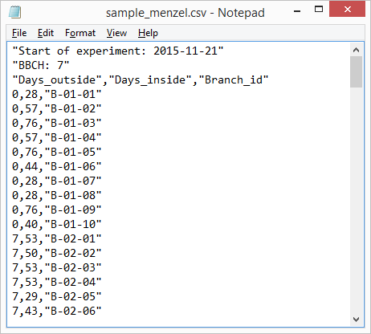

**Bud Development Model:**

- to estimate forcing conditions by indicating the mean indoor room temperature
- to import the corresponding outdoor temperatures by selecting the nearest available climate station
- to fit the chilling (chilling days, CD) and forcing (growing degree days, GDD) model
  $$GDD_{crit} = a + b * ln{CD}$$
  by setting up the thresholds (by default 5$^\circ$C threshold)

**Climate Change Simulator:**

- to simulate future bud development for a chosen base year (i.e. the year of the corresponding autumn / winter before the simulated spring)
- to run winter and / or spring warming scenarios from -1$^\circ$C to +5$^\circ$C

### Authors

Y. Yuan, M. Matiu, A. Menzel

Ecoclimatology, Department of Ecology and Ecosystem Management, TUM School of Life Sciences, Technical University of Munich, Freising, Germany

### Contact

yuan@wzw.tum.de